# act_report

## We Rate Dogs

Have you heard of We Rate Dogs account? The We Rate Dogs account provides us with evaluations of dogs and shows us different types of dogs with pictures of them. It is a really good account. Now I will present to you some analyzes that I took through the tweets of this account, and I will present them to you.

After looking at the pie chart, we can tell from the pie chart that there are 84.6% of the tweets that do not provide us with information about the stage of the dog. We can also see from those who gave us information about the dog stage that the most popular stage among them is the Popper, which is the highest in tweets. As for the less popular among the stages of the dog is the Floofer and it comes with fewer tweets

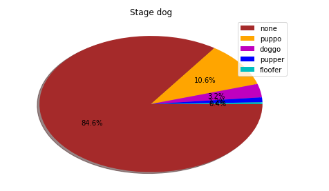

We also found the most liked tweet by Twitter users, and it was received by the Puppo (dog stage) and we can see there the Puppo (dog stage) take more than 130000 likes and he take more than 48000 retweets.

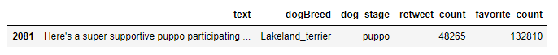

We also found the Lowest liked tweet by Twitter users, and it was received by the English_setter(dogBreed) and we can see there the English_setter(dogBreed) take more than 80 likes and he take more than 15 retweets.

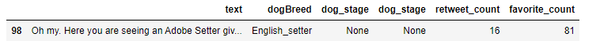

and we also found the most retweet tweet by Twitter users, and it was received by the doggo (dog stage) and he take more than 79000 retweets and in the same time he take more than 130000 likes.

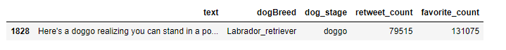

We can also see here that there is a convergence in the number of likes among them.